# Analysis of deltaHb - ferritin association

# Initialization

## Load packages

**Libraries**

```r
library("Hmisc")
library("zoo")
library("mcp") # for bayesian changepoint analysis
library("rjags")
library("pracma")
library("scales")
library("dplyr")
#load the functions needed
source("~/proj/who_ferritin_comment/src/1_Functions_Finland.R")
```

## Directories

In this part of the code we ask you to define:

- Your main directory (in which we will create a subdirectory for the bootstrap results and where the functions file is located)
- Your data file
- The folder to which we export results (more on this later in the document)

```r
#define your main directory
subsetname <- "no_washout_all_all"
main_dir <- "~/proj/who_ferritin_comment/data/FerHb" #define your main directory
FileToUse <- paste0("~/proj/who_ferritin_comment/data/FerHb/subsets/", subsetname, ".rds") #define the dataset file you want to use for the analysis (1 of 6 datasets we agreed on)
export_folder <- "results_export" #define the name of the folder you want to export you results to
```

```r
setwd(main_dir)
# setting up the sub directory for bootstrap results and a folder with today's date
sub_dir <- "bootstrap_results"
currentDate <- Sys.Date()

# check if sub directory already exists, otherwise create it
if (file.exists(sub_dir)){
      print("The folder for bootstrap results already exists")
} else {
        # create a new sub directory inside
        # the main path
        dir.create(file.path(main_dir, sub_dir))
}
```

```
[1] "The folder for bootstrap results already exists"
```

```r
#check if the folder for today's bootstrap results already exists, otherwise create it
if (file.exists(file.path(sub_dir,currentDate))){
      print("Today's sub folder already exists")
} else {
        # create a new sub directory inside
        # the main path
        dir.create(file.path(main_dir, sub_dir,currentDate))
}
```

```
[1] "Today's sub folder already exists"
```

```r
#check if the folder for result export already exists, otherwise create it
if (file.exists(export_folder)){
      print("The folder for the result export already exists")
} else {
        # create a new sub directory inside
        # the main path
        dir.create(file.path(main_dir, export_folder))
}
```

```
[1] "The folder for the result export already exists"
```

```r
if (file.exists(file.path(export_folder, currentDate))){
      print("Today's sub folder already exists")
} else {
        # create a new sub directory inside
        # the main path
        dir.create(file.path(main_dir, export_folder,currentDate))
}
```

```
[1] "Today's sub folder already exists"
```

```r
if(grepl("dataset1", FileToUse)){FolderDataset <<- "dataset1"} else if (grepl("dataset2", FileToUse)){FolderDataset <<- "dataset2"} else if (grepl("dataset3", FileToUse)){FolderDataset <<- "dataset3"} else if (grepl("dataset4", FileToUse)){FolderDataset <<- "dataset4"} else if (grepl("dataset5", FileToUse)){FolderDataset <<- "dataset5"} else if (grepl("dataset6", FileToUse)){FolderDataset <<- "dataset6"} else (FolderDataset <- format(Sys.time(), "%H_%M"))
```

```
[1] "12_58"
```

```r
if (file.exists(file.path(export_folder, currentDate, FolderDataset))){
      print("A sub folder with this time stamp already exists")
} else {
        # create a new sub directory inside
        # the main path
        dir.create(file.path(main_dir, export_folder,currentDate, FolderDataset))
}

raw_data <- readRDS(FileToUse)
data <- conform(raw_data)

#if(!is.factor(data$Geslacht)){data$Geslacht<-as.factor(data$Geslacht)}
```

## Parameters

Here you have to define some parameters:

```r
#plotting and analysis
menopausal_status <- T # indicate whether you want to additionally split the females by their menopausal status

#simulation
dobayes<-F         # Indicate whether you want to perform a bayesian changepoint analysis (recommended: F)
dobootstrap<-T     # Indicate whether you want to perform a bootstrap of the max likelihood estimate for the changepoint (recommended: T)
printbootstrap<-F  # Indicate whether you want to print the bootstrap results. For readable quarto files this is not recommended (recommended: F)
nrbssims<-2       # nr of bootstrapsamples (recommended: 200, if you just want to test the script a low value is recommended (e.g. 2))
bsseed<-2          # seedvalue for the bootstrap

rollmean_nr<-1000  # nr of samples to use in the rolling maen

#exporting results
export_files <- T # Indicate whether you want to export the results of the analysis
proportion <- 0.03 # proportion of your data that you will export. This really depends on how big your data is. We recommend a proportion that will still display the pattern/direction of the data.

# lower and upper limits for the changepoint fit
# these consist of the intercept, slope, changepoint and standard deviation of the error
ll=c(-2, 0.005, 0.5, 0.3) # lower limit (recommended: c(-2, 0.005, 0.5, 0.3))
#ll=c(-2, 0.005,  -4, 0.3) # lower limit (recommended: c(-2, 0.005,  -4, 0.3))
ul=c( 1,     2,   4, 0.9) # upper limit (c( 1,     2,   4, 0.9))
```

**A note on exporting results**

Only jittered values or values derived from analyses are exported.

When exporting the data, the dRefHb value and lFer variables are jittered, all the original values are removed before exporting. Original values are removed from the results of the analysis when exporting. Only the result of the analysis is exported

We export the results so we can, ultimately, combine results from all countries in one graph.

# Changepoint analysis

**analysis**

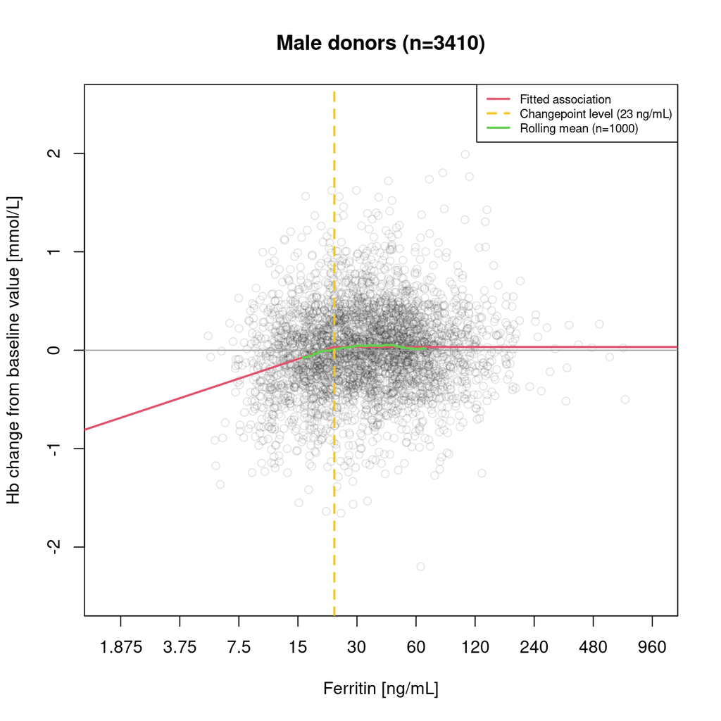

```
[1] "-0.866779491222431 0.660731864000821 1.36172783577483 0.441893351703184 0 26"
[1] "Changepoint: 22.9999999871432"
[1] "SolutionOk: TRUE"
```

```r
### set male dataset for reference
refdata<-select_males_only()
refdata<-refdata[order(refdata$lFer),] # order data by lFer
refdataM<-refdata
fitdata<-refdata
title=paste0("Male donors (n=", nrow(refdataM),")", sep="")
xm<-plotHbFer()
```

**analysis**

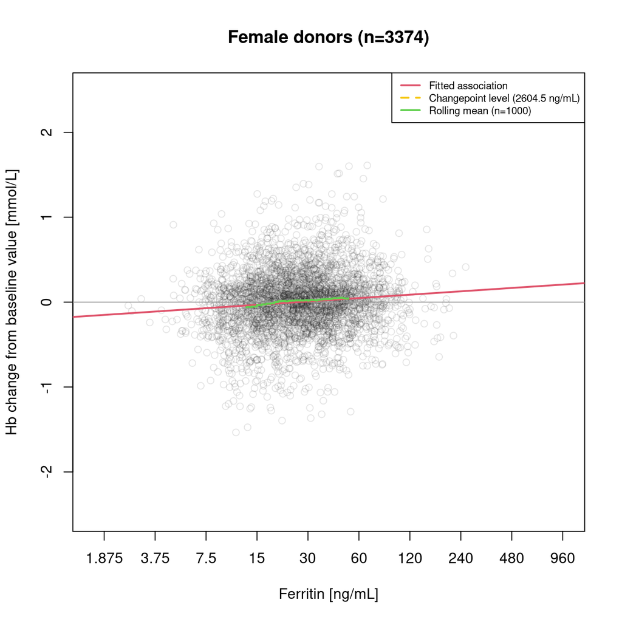

```
[1] "-0.186644740899899 0.131837388848737 3.41571933826788 0.371690300939784 0 26"
[1] "Changepoint: 2604.46987382338"
[1] "SolutionOk: TRUE"
```

```r
if(export_files){
  exportData(refdataM)
  exportRollmean(rollmean_data)
  exportSolution(sol_data)
  }

### set female dataset for reference
refdata<-select_females_only()
refdata<-refdata[order(refdata$lFer),] # order data by lFer
refdataF<-refdata
fitdata<-refdata
title=paste0("Female donors (n=", nrow(refdataF), ")", sep="")
xf<-plotHbFer()
```

**analysis**

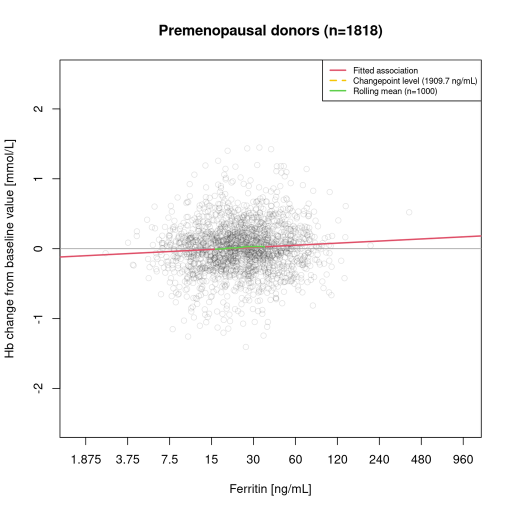

```
[1] "-0.127450817203468 0.0994955144864992 3.28097048255138 0.358457242933725 0 26"
[1] "Changepoint: 1909.72345705583"
[1] "SolutionOk: TRUE"
```

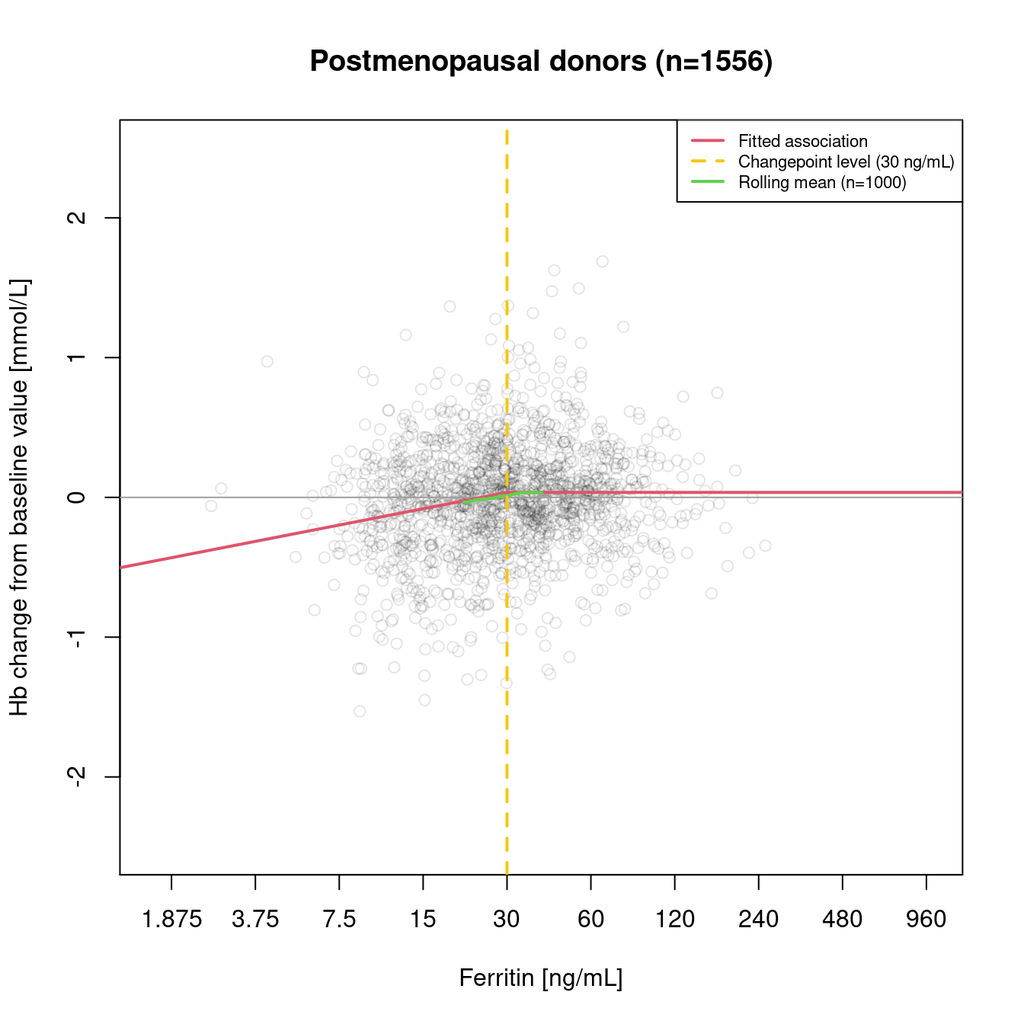

```
[1] "-0.537286011732474 0.387931159667538 1.47712125630721 0.383617219756737 0 26"
[1] "Changepoint: 30.0000001096639"
[1] "SolutionOk: TRUE"
```

```r
if(export_files){
  exportData(refdataF)
  exportRollmean(rollmean_data)
  changepoint_data <- rbind(xm, xf)
  exportSolution(sol_data)}

if(menopausal_status){
## set premenopausal female dataset for reference
refdata<-select_premenopausal_only()
refdata<-refdata[order(refdata$lFer),] # order data by lFer
refdatapreF<-refdata
fitdata<-refdata
title=paste0("Premenopausal donors (n=", nrow(refdatapreF), ")", sep="")
xpref<-plotHbFer()
if(export_files){
  exportData(refdatapreF)
  exportRollmean(rollmean_data)
  exportSolution(sol_data)}

## set postmenopausal female dataset for reference
refdata<-select_postmenopausal_only()
refdata<-refdata[order(refdata$lFer),] # order data by lFer
refdatapostF<-refdata
fitdata<-refdata
title=paste0("Postmenopausal donors (n=", nrow(refdatapostF), ")", sep="")
xpostf<-plotHbFer()
if(export_files){
  exportData(refdatapostF)
  exportRollmean(rollmean_data)
  exportSolution(sol_data)}

changepoint_data <- rbind(xm, xf, xpref, xpostf)}
```

# Bootstrap results

## Run bootstrap

Bootstrap will run only if set to T in parameters.

**bootstrap**

```r
if(dobootstrap){

### set male dataset for reference
refdata<-select_males_only()
refdata<-refdata[order(refdata$lFer),]
nrow(refdata)
length(unique(refdata$KeyID))
nrow(refdata)/length(unique(refdata$KeyID))
sum(refdata$Ferritin<=30)/nrow(refdata)
length(unique(refdata$KeyID[refdata$Ferritin<=30]))
length(unique(refdata$KeyID[refdata$Ferritin<=30]))/length(unique(refdata$KeyID))


# copy reference dataset for fitting models (and bootstrapping)
refdataM<-refdata
#fitdata<-fitdata[1:1000,]
### plot lFer vs dRefHb
#xm<-plotHbFer()

### set female dataset for reference
refdata<-select_females_only()
refdata<-refdata[order(refdata$lFer),]
nrow(refdata)
length(unique(refdata$KeyID))
nrow(refdata)/length(unique(refdata$KeyID))
sum(refdata$Ferritin<=30)/nrow(refdata)
length(unique(refdata$KeyID[refdata$Ferritin<=30]))
length(unique(refdata$KeyID[refdata$Ferritin<=30]))/length(unique(refdata$KeyID))

# copy reference dataset for fitting models (and bootstrapping)
refdataF<-refdata
#fitdata<-fitdata[1:1000,]
#xf<-plotHbFer()
if(menopausal_status){
### set premenopausal dataset for reference
refdata<-select_premenopausal_only()
refdata<-refdata[order(refdata$lFer),]
nrow(refdata)
length(unique(refdata$KeyID))
nrow(refdata)/length(unique(refdata$KeyID))
sum(refdata$Ferritin<=30)/nrow(refdata)
length(unique(refdata$KeyID[refdata$Ferritin<=30]))
length(unique(refdata$KeyID[refdata$Ferritin<=30]))/length(unique(refdata$KeyID))

# copy reference dataset for fitting models (and bootstrapping)
refdatapreF<-refdata
#fitdata<-fitdata[1:1000,]
#xpref<-plotHbFer()

### set postmenopausal dataset for reference
refdata<-select_postmenopausal_only()
refdata<-refdata[order(refdata$lFer),]
nrow(refdata)
length(unique(refdata$KeyID))
nrow(refdata)/length(unique(refdata$KeyID))
sum(refdata$Ferritin<=30)/nrow(refdata)
length(unique(refdata$KeyID[refdata$Ferritin<=30]))
length(unique(refdata$KeyID[refdata$Ferritin<=30]))/length(unique(refdata$KeyID))

# copy reference dataset for fitting models (and bootstrapping)
refdatapostF<-refdata
#fitdata<-fitdata[1:1000,]
#xpostf<-plotHbFer()
}
rm(data)
while (!is.null(dev.list())) dev.off()

for (bsseed in 1:5) {

if(printbootstrap){  print("")
  print(paste("seed =",bsseed))
  print("")}

  ### bootstrap this result
  refdata<-refdataM
  fitdata<-refdataM
  bsxm<-c()
  nr<-nrow(fitdata)
  set.seed(bsseed)
  for (i in 1:nrbssims){
    fitdata<-refdata[sample(1:nr, nr, replace = T), c("lFer","dRefHb")]
    bsr<-fminsearch(fitf, xm, lower=ll, upper=ul, method="Hooke-Jeeves")
    bsxm<-rbind(bsxm, c(bsr$xmin, bsr$convergence, bsr$info$iterations, SolutionOk(bsr$xmin)))
    # print(paste(i,":",paste(bsr$xmin, collapse = " "), bsr$convergence, bsr$info$iterations))
    if(printbootstrap){print(paste(i,":",paste(bsxm[i,], collapse = " ")))}
  }
  MaleBootstrapResultFile<-paste0("~/proj/who_ferritin_comment/data/FerHb/bootstrap_results/", Sys.Date(), "/", subsetname, "_", "Male_Bootstrap_", nrbssims,"_samp_",bsseed, "seed.RDS")
  saveRDS(bsxm, file=MaleBootstrapResultFile)
}

for (bsseed in 1:5) {

if(printbootstrap){  print("")
  print(paste("seed =",bsseed))
  print("")}

  ### now bootstrap this result
  refdata<-refdataF
  fitdata<-refdataF
  bsxf<-c()
  nr<-nrow(fitdata)
  set.seed(bsseed)
  for (i in 1:nrbssims){
    fitdata<-refdata[sample(1:nr, nr, replace = T), c("lFer","dRefHb")]
    bsr<-fminsearch(fitf, xf, lower=ll, upper=ul, method="Hooke-Jeeves")
    bsxf<-rbind(bsxf, c(bsr$xmin, bsr$convergence, bsr$info$iterations, SolutionOk(bsr$xmin)))
    # print(paste(i,":",paste(bsr$xmin, collapse = " "), bsr$convergence, bsr$info$iterations))
    if(printbootstrap){print(paste(i,":",paste(bsxf[i,], collapse = " ")))}
  }
  FemaleBootstrapResultFile <-paste0("~/proj/who_ferritin_comment/data/FerHb/bootstrap_results/", Sys.Date(), "/", subsetname, "_", "Female_Bootstrap_",nrbssims,"_samp_", bsseed, "seed.RDS")
  saveRDS(bsxf, file=FemaleBootstrapResultFile)

}
if(menopausal_status){
  for (bsseed in 1:5) {

if(printbootstrap){  print("")
  print(paste("seed =",bsseed))
  print("")
  }
  ### now bootstrap this result
  refdata<-refdatapreF
  fitdata<-refdatapreF
  bsxpref<-c()
  nr<-nrow(fitdata)
  set.seed(bsseed)
  for (i in 1:nrbssims){
    fitdata<-refdata[sample(1:nr, nr, replace = T), c("lFer","dRefHb")]
    bsr<-fminsearch(fitf, xpref, lower=ll, upper=ul, method="Hooke-Jeeves")
    bsxpref<-rbind(bsxpref, c(bsr$xmin, bsr$convergence, bsr$info$iterations, SolutionOk(bsr$xmin)))
    # print(paste(i,":",paste(bsr$xmin, collapse = " "), bsr$convergence, bsr$info$iterations))
    if(printbootstrap){print(paste(i,":",paste(bsxpref[i,], collapse = " ")))}
  }
  PremenopausalBootstrapResultFile<-paste0("~/proj/who_ferritin_comment/data/FerHb/bootstrap_results/", Sys.Date(), "/", subsetname, "_", "Premenopausal_Bootstrap_",nrbssims,"_samp_", bsseed, "seed.RDS")
  saveRDS(bsxpref, file=PremenopausalBootstrapResultFile)

  }
  for (bsseed in 1:5) {

if(printbootstrap){  print("")
  print(paste("seed =",bsseed))
  print("")}

  ### now bootstrap this result
  refdata<-refdatapostF
  fitdata<-refdatapostF
  bsxpostf<-c()
  nr<-nrow(fitdata)
  set.seed(bsseed)
  for (i in 1:nrbssims){
    fitdata<-refdata[sample(1:nr, nr, replace = T), c("lFer","dRefHb")]
    bsr<-fminsearch(fitf, xpostf, lower=ll, upper=ul, method="Hooke-Jeeves")
    bsxpostf<-rbind(bsxpostf, c(bsr$xmin, bsr$convergence, bsr$info$iterations, SolutionOk(bsr$xmin)))
    # print(paste(i,":",paste(bsr$xmin, collapse = " "), bsr$convergence, bsr$info$iterations))
    if(printbootstrap){print(paste(i,":",paste(bsxpostf[i,], collapse = " ")))}
  }
  PostmenopausalBootstrapResultFile<-paste0("~/proj/who_ferritin_comment/data/FerHb/bootstrap_results/", Sys.Date(), "/", subsetname, "_", "Postmenopausal_Bootstrap_",nrbssims,"_samp_", bsseed, "seed.RDS")
  saveRDS(bsxpostf, file=PostmenopausalBootstrapResultFile)

}
}

}
```